# **MATH 3190 Homework 6**

Due March 5, 2026  
Focus: Notes 7 Part 2  
Total Points: 90 + 10 (Self-Critique Comment and Uploading to GitHub) = 100

Note that your homework should be completed in Quarto. You can just add your answers and code to this document in the appropriate part. The file should be rendered as an html document or pdf document (html is quicker to render and you will need an installation of LaTeX to render as a pdf). You will “turn in” this homework by uploading the files, the .qmd and output file, to your GitHub `Math_3190_Assignment` repository in the `Homework/Homework_6` directory. Make sure all supporting files (if there are any) are in this directory as well. You should use `git` and `Unix` commands in a terminal for this (i.e. don’t manually upload files to GitHub). In addition, you will submit just your html or pdf file on Canvas to unlock the solutions.

Don’t forget to also put a self-critique comment on Canvas indicating what you did correctly and incorrectly and include any questions you may have about the assignment after submitting the assignment and thoroughly looking through the solutions.

```r
library(tidyverse) |> suppressPackageStartupMessages()
library(math3190package) |> suppressPackageStartupMessages()
library(glmnet) |> suppressPackageStartupMessages()
library(glmnetUtils) |> suppressPackageStartupMessages()
library(faraway) |> suppressPackageStartupMessages()
library(caret) |> suppressPackageStartupMessages()
library(AER) |> suppressPackageStartupMessages()
```

# Problem 1 (28 points)

An automobile consulting company wants to understand the factors on which the pricing of cars depends. The dataset `car_price_prediction` in the `math3190package` (and also found in the GitHub data folder) has information on the sales of 4340 vehicles.

### Part a (3 points)

Create new variables in the dataset by taking the natural log of selling price, year, and km_driven. This will help linearize the association between variables. Then fit a linear model for predicting the log of selling price using all other variables except “name”, “year”, “selling_price”, and “km_driven” (the logged variables should be used instread of those last three). Also, there is only one vehicle with a fuel type of “Electric”. Remove that vehicle from the dataset.

```r
cars <- car_price_prediction |>
  mutate(
    log_selling_price = log(selling_price),
    log_year = log(year),
    log_km_driven = log(km_driven)
    ) |>
  filter(fuel != "Electric")

mod1lm <- lm(log_selling_price ~ . - name - year - selling_price - km_driven, data = cars)
summary(mod1lm)
```

```
Call:
lm(formula = log_selling_price ~ . - name - year - selling_price -
    km_driven, data = cars)

Residuals:
     Min       1Q   Median       3Q      Max
-1.81328 -0.30396  0.00055  0.28820  2.32756

Coefficients:
                              Estimate Std. Error t value Pr(>|t|)
(Intercept)                 -1.686e+03  3.345e+01 -50.406  < 2e-16 ***
fuelDiesel                   5.842e-01  7.526e-02   7.763 1.03e-14 ***
fuelLPG                     -5.132e-02  1.233e-01  -0.416 0.677337
fuelPetrol                   6.553e-02  7.539e-02   0.869 0.384754
seller_typeIndividual       -1.555e-01  1.817e-02  -8.555  < 2e-16 ***
seller_typeTrustmark Dealer  3.089e-01  4.910e-02   6.292 3.45e-10 ***
transmissionManual          -8.001e-01  2.432e-02 -32.897  < 2e-16 ***
ownerFourth & Above Owner   -1.418e-01  5.502e-02  -2.577 0.010003 *
ownerSecond Owner           -4.521e-02  1.840e-02  -2.458 0.014024 *
ownerTest Drive Car          7.418e-02  1.192e-01   0.622 0.533702
ownerThird Owner            -1.156e-01  3.058e-02  -3.780 0.000159 ***
log_year                     2.234e+02  4.389e+00  50.896  < 2e-16 ***
log_km_driven               -3.601e-02  1.010e-02  -3.566 0.000366 ***
---
Signif. codes:  0 '***' 0.001 '**' 0.01 '*' 0.05 '.' 0.1 ' ' 1

Residual standard error: 0.4705 on 4326 degrees of freedom
Multiple R-squared:  0.6866,    Adjusted R-squared:  0.6858
F-statistic: 789.9 on 12 and 4326 DF,  p-value: < 2.2e-16
```

### Part b (5 points)

Now fit some LASSO models for predicting log selling price using all but the “name” variable. Try the following values for the regularization parameter: $\lambda=0,\ 0.01,\ 0.1,$ and $1$ and comment on how the coefficients of the model change.

Note: when $\lambda=0$, the LASSO coefficients should equal the OLS model coefficients. However, they will actually be a bit off here. That is because the `glmnet()` function has a `thresh` argument that sets a threshold for convergence. It is, by default, set to `1e-07`. To make the parameters match, you can change that to `thresh = 1e-14` instead. This is not necessary, though.

```r
mod1lasso <- glmnet(log_selling_price ~ . - name, data = cars, alpha = 1)
lambda <- c(0, 0.01, 0.1, 1)
results_list <- list()

for (l in lambda) {
  cat("\n--- Lambda:", l, "---\n")
  print(coef(mod1lasso, s = l))

  column_name <- paste0("lambda_", l)
  results_list[[column_name]] <- as.matrix(coef(mod1lasso, s = l))[,1]
}
```

```
--- Lambda: 0 ---
20 x 1 sparse Matrix of class "dgCMatrix"
                                      s=0
(Intercept)                 -1.824324e+02
year                         8.544395e-02
selling_price                7.255059e-07
km_driven                    2.342955e-07
fuelCNG                     -6.119756e-02
fuelDiesel                   2.996933e-01
fuelLPG                     -1.399522e-01
fuelPetrol                   .
seller_typeDealer            .
seller_typeIndividual       -1.075524e-01
seller_typeTrustmark Dealer  1.781800e-01
transmissionAutomatic        1.666474e-01
transmissionManual          -1.098192e-12
ownerFirst Owner             1.474065e-02
ownerFourth & Above Owner   -1.124192e-01
ownerSecond Owner            .
ownerTest Drive Car          3.284238e-02
ownerThird Owner            -6.537175e-02
log_year                     2.986201e+00
log_km_driven                .

--- Lambda: 0.01 ---
20 x 1 sparse Matrix of class "dgCMatrix"
                                   s=0.01
(Intercept)                 -1.775575e+02
year                         8.425654e-02
selling_price                7.266744e-07
km_driven                    .
fuelCNG                      .
fuelDiesel                   2.932229e-01
fuelLPG                     -3.278518e-02
fuelPetrol                   .
seller_typeDealer            .
seller_typeIndividual       -9.982522e-02
seller_typeTrustmark Dealer  1.329586e-01
transmissionAutomatic        1.435525e-01
transmissionManual          -5.804635e-13
```

[output cut: 40 more lines]

```
fuelDiesel                   .
fuelLPG                      .
fuelPetrol                   .
seller_typeDealer            .
seller_typeIndividual        .
seller_typeTrustmark Dealer  .
transmissionAutomatic        .
transmissionManual           .
ownerFirst Owner             .
ownerFourth & Above Owner    .
ownerSecond Owner            .
ownerTest Drive Car          .
ownerThird Owner             .
log_year                     .
log_km_driven                .
```

```r
coef_tibble_lasso <- as_tibble(results_list) |>
  mutate(variable = rownames(as.matrix(coef(mod1lasso, s = 0)))) |>
  select(variable, everything())

print(coef_tibble_lasso)
```

```
# A tibble: 20 × 5
   variable                     lambda_0 lambda_0.01 lambda_0.1 lambda_1
   <chr>                           <dbl>       <dbl>      <dbl>    <dbl>
 1 (Intercept)                 -1.82e+ 2   -1.78e+ 2   -1.46e+2     12.8
 2 year                         8.54e- 2    8.43e- 2    7.12e-2      0
 3 selling_price                7.26e- 7    7.27e- 7    7.16e-7      0
 4 km_driven                    2.34e- 7    0           0            0
 5 fuelCNG                     -6.12e- 2    0           0            0
 6 fuelDiesel                   3.00e- 1    2.93e- 1    1.38e-1      0
 7 fuelLPG                     -1.40e- 1   -3.28e- 2    0            0
 8 fuelPetrol                   0           0           0            0
 9 seller_typeDealer            0           0           0            0
10 seller_typeIndividual       -1.08e- 1   -9.98e- 2    0            0
11 seller_typeTrustmark Dealer  1.78e- 1    1.33e- 1    0            0
12 transmissionAutomatic        1.67e- 1    1.44e- 1    0            0
13 transmissionManual          -1.10e-12   -5.80e-13    0            0
14 ownerFirst Owner             1.47e- 2    8.91e- 3    0            0
15 ownerFourth & Above Owner   -1.12e- 1   -5.93e- 2    0            0
16 ownerSecond Owner            0           0           0            0
17 ownerTest Drive Car          3.28e- 2    0           0            0
18 ownerThird Owner            -6.54e- 2   -3.60e- 2    0            0
19 log_year                     2.99e+ 0    2.66e+ 0    1.94e+0      0
20 log_km_driven                0           0           0            0
```

Answer: As the lambda increases, more coefficients converge to 0, leaving the most significant drivers for logged selling price.

### Part c (4 points)

Now fit some ridge regression models for predicting log selling price using all but name. Try the following values for the regularization parameter: $\lambda=0,\ 0.01,\ 0.1,$ and $1$ and comment on how the coefficients of the model change.

```r
mod1ridge <- list()
coef_columns <- list()
lambda_values <- c(0, 0.01, 0.1, 1)

for (i in seq_along(lambda_values)) {
  l <- lambda_values[i]

  mod1ridge[[i]] <- glmnet(log_selling_price ~ . - name, data = cars, alpha = 0, lambda = l)

  column_name <- paste0("lambda_", l)
  coef_columns[[column_name]] <- as.matrix(coef(mod1ridge[[i]]))[,1]

  cat("\n--- Ridge Results for Lambda:", l, "---\n")
  print(coef(mod1ridge[[i]]))
}
```

```
--- Ridge Results for Lambda: 0 ---
20 x 1 sparse Matrix of class "dgCMatrix"
                                       s0
(Intercept)                  5.141812e+02
year                         1.380487e-01
selling_price                7.249216e-07
km_driven                    3.773111e-07
fuelCNG                     -7.898886e-02
fuelDiesel                   2.972341e-01
fuelLPG                     -1.632554e-01
fuelPetrol                  -3.690745e-03
seller_typeDealer            7.380581e-02
seller_typeIndividual       -3.500476e-02
seller_typeTrustmark Dealer  2.609147e-01
transmissionAutomatic        1.712015e-01
transmissionManual          -1.268493e-13
ownerFirst Owner             3.997644e-02
ownerFourth & Above Owner   -9.925379e-02
ownerSecond Owner            2.367193e-02
ownerTest Drive Car          6.947983e-02
ownerThird Owner            -4.742598e-02
log_year                    -1.025107e+02
log_km_driven               -5.123401e-03

--- Ridge Results for Lambda: 0.01 ---
20 x 1 sparse Matrix of class "dgCMatrix"
                                       s0
(Intercept)                 -7.056814e+02
year                         4.586184e-02
selling_price                7.125456e-07
km_driven                    3.401283e-07
fuelCNG                     -2.131534e-01
fuelDiesel                   1.631709e-01
fuelLPG                     -2.979832e-01
fuelPetrol                  -1.411214e-01
seller_typeDealer            4.273204e-02
seller_typeIndividual       -6.620719e-02
seller_typeTrustmark Dealer  2.304101e-01
transmissionAutomatic        9.362359e-02
transmissionManual          -8.845253e-02
```

[output cut: 40 more lines]

```
fuelDiesel                   1.550265e-01
fuelLPG                     -2.035537e-01
fuelPetrol                  -1.463286e-01
seller_typeDealer            5.198041e-02
seller_typeIndividual       -7.059148e-02
seller_typeTrustmark Dealer  1.805840e-01
transmissionAutomatic        1.854973e-01
transmissionManual          -1.854923e-01
ownerFirst Owner             6.736411e-02
ownerFourth & Above Owner   -1.511797e-01
ownerSecond Owner           -3.704605e-02
ownerTest Drive Car          1.258916e-01
ownerThird Owner            -9.142243e-02
log_year                     6.145928e+01
log_km_driven               -3.165648e-02
```

```r
coef_tibble_ridge <- as_tibble(coef_columns) |>
  mutate(term = rownames(as.matrix(coef(mod1ridge[[1]])))) |>
  select(term, everything())

print(coef_tibble_ridge)
```

```
# A tibble: 20 × 5
   term                         lambda_0 lambda_0.01 lambda_0.1 lambda_1
   <chr>                           <dbl>       <dbl>      <dbl>    <dbl>
 1 (Intercept)                  5.14e+ 2    -7.06e+2   -7.11e+2 -5.16e+2
 2 year                         1.38e- 1     4.59e-2    4.20e-2  3.06e-2
 3 selling_price                7.25e- 7     7.13e-7    6.21e-7  3.25e-7
 4 km_driven                    3.77e- 7     3.40e-7    1.73e-7 -3.38e-7
 5 fuelCNG                     -7.90e- 2    -2.13e-1   -2.03e-1 -1.22e-1
 6 fuelDiesel                   2.97e- 1     1.63e-1    1.70e-1  1.55e-1
 7 fuelLPG                     -1.63e- 1    -2.98e-1   -2.90e-1 -2.04e-1
 8 fuelPetrol                  -3.69e- 3    -1.41e-1   -1.56e-1 -1.46e-1
 9 seller_typeDealer            7.38e- 2     4.27e-2    4.33e-2  5.20e-2
10 seller_typeIndividual       -3.50e- 2    -6.62e-2   -6.84e-2 -7.06e-2
11 seller_typeTrustmark Dealer  2.61e- 1     2.30e-1    2.31e-1  1.81e-1
12 transmissionAutomatic        1.71e- 1     9.36e-2    1.28e-1  1.85e-1
13 transmissionManual          -1.27e-13    -8.85e-2   -1.27e-1 -1.85e-1
14 ownerFirst Owner             4.00e- 2     2.42e-2    3.40e-2  6.74e-2
15 ownerFourth & Above Owner   -9.93e- 2    -1.18e-1   -1.31e-1 -1.51e-1
16 ownerSecond Owner            2.37e- 2     5.08e-3   -4.30e-3 -3.70e-2
17 ownerTest Drive Car          6.95e- 2     5.82e-2    7.75e-2  1.26e-1
18 ownerThird Owner            -4.74e- 2    -6.60e-2   -7.49e-2 -9.14e-2
19 log_year                    -1.03e+ 2     8.23e+1    8.40e+1  6.15e+1
20 log_km_driven               -5.12e- 3    -5.71e-3   -1.37e-2 -3.17e-2
```

### Part d (4 points)

Now fit some elastic net regression models for predicting log price using all but name. Try the following values for the regularization parameter: $\lambda=0,\ 0.01,\ 0.1,$ and $1$ for $\alpha=1/3$ and then comment on how the coefficients of the model change for each $\alpha$ from parts (b), (c), and (d).

```r
mod1elastic <- list()
coef_columns <- list()
lambda_values <- c(0, 0.01, 0.1, 1)

for (i in seq_along(lambda_values)) {
  l <- lambda_values[i]

  mod1elastic[[i]] <- glmnet(log_selling_price ~ . - name, data = cars, alpha = 1/3, lambda = l)

  column_name <- paste0("lambda_", l)
  coef_columns[[column_name]] <- as.matrix(coef(mod1elastic[[i]]))[,1]

  cat("\n--- Elastic Results for Lambda:", l, "---\n")
  print(coef(mod1elastic[[i]]))
}
```

```
--- Elastic Results for Lambda: 0 ---
20 x 1 sparse Matrix of class "dgCMatrix"
                                       s0
(Intercept)                  5.141812e+02
year                         1.380487e-01
selling_price                7.249216e-07
km_driven                    3.773111e-07
fuelCNG                     -7.898886e-02
fuelDiesel                   2.972341e-01
fuelLPG                     -1.632554e-01
fuelPetrol                  -3.690745e-03
seller_typeDealer            7.380581e-02
seller_typeIndividual       -3.500476e-02
seller_typeTrustmark Dealer  2.609147e-01
transmissionAutomatic        1.712015e-01
transmissionManual          -1.268493e-13
ownerFirst Owner             3.997644e-02
ownerFourth & Above Owner   -9.925379e-02
ownerSecond Owner            2.367193e-02
ownerTest Drive Car          6.947983e-02
ownerThird Owner            -4.742598e-02
log_year                    -1.025107e+02
log_km_driven               -5.123401e-03

--- Elastic Results for Lambda: 0.01 ---
20 x 1 sparse Matrix of class "dgCMatrix"
                                       s0
(Intercept)                 -7.018545e+02
year                         4.576140e-02
selling_price                7.177066e-07
km_driven                    1.354582e-07
fuelCNG                     -5.065510e-02
fuelDiesel                   2.934383e-01
fuelLPG                     -1.236467e-01
fuelPetrol                  -6.564690e-03
seller_typeDealer            .
seller_typeIndividual       -1.058975e-01
seller_typeTrustmark Dealer  1.691608e-01
transmissionAutomatic        8.919929e-02
transmissionManual          -7.947466e-02
```

[output cut: 40 more lines]

```
fuelDiesel                   .
fuelLPG                      .
fuelPetrol                   .
seller_typeDealer            .
seller_typeIndividual        .
seller_typeTrustmark Dealer  .
transmissionAutomatic        .
transmissionManual           .
ownerFirst Owner             .
ownerFourth & Above Owner    .
ownerSecond Owner            .
ownerTest Drive Car          .
ownerThird Owner             .
log_year                     3.215727e+01
log_km_driven                .
```

```r
coef_tibble_elastic <- as_tibble(coef_columns) |>
  mutate(term = rownames(as.matrix(coef(mod1elastic[[1]])))) |>
  select(term, everything())

print(coef_tibble_elastic)
```

```
# A tibble: 20 × 5
   term                         lambda_0 lambda_0.01 lambda_0.1 lambda_1
   <chr>                           <dbl>       <dbl>      <dbl>    <dbl>
 1 (Intercept)                  5.14e+ 2    -7.02e+2   -7.01e+2 -2.64e+2
 2 year                         1.38e- 1     4.58e-2    4.16e-2  1.60e-2
 3 selling_price                7.25e- 7     7.18e-7    6.61e-7  2.60e-7
 4 km_driven                    3.77e- 7     1.35e-7    0        0
 5 fuelCNG                     -7.90e- 2    -5.07e-2    0        0
 6 fuelDiesel                   2.97e- 1     2.93e-1    2.06e-1  0
 7 fuelLPG                     -1.63e- 1    -1.24e-1    0        0
 8 fuelPetrol                  -3.69e- 3    -6.56e-3   -5.11e-2  0
 9 seller_typeDealer            7.38e- 2     0          0        0
10 seller_typeIndividual       -3.50e- 2    -1.06e-1   -8.12e-2  0
11 seller_typeTrustmark Dealer  2.61e- 1     1.69e-1    3.06e-2  0
12 transmissionAutomatic        1.71e- 1     8.92e-2    7.41e-2  0
13 transmissionManual          -1.27e-13    -7.95e-2   -7.34e-2  0
14 ownerFirst Owner             4.00e- 2     1.46e-2    6.81e-3  0
15 ownerFourth & Above Owner   -9.93e- 2    -1.02e-1    0        0
16 ownerSecond Owner            2.37e- 2     0          0        0
17 ownerTest Drive Car          6.95e- 2     7.76e-3    0        0
18 ownerThird Owner            -4.74e- 2    -5.91e-2    0        0
19 log_year                    -1.03e+ 2     8.18e+1    8.28e+1  3.22e+1
20 log_km_driven               -5.12e- 3     0          0        0
```

Answer: We can see that like the lasso regression, variables converge to 0 as the lambda increases. However, unlike the lasso in this case, by lambda = 1, there are still variables that are not dropped.

```r
# Part b
print(coef_tibble_lasso)
```

```
# A tibble: 20 × 5
   variable                     lambda_0 lambda_0.01 lambda_0.1 lambda_1
   <chr>                           <dbl>       <dbl>      <dbl>    <dbl>
 1 (Intercept)                 -1.82e+ 2   -1.78e+ 2   -1.46e+2     12.8
 2 year                         8.54e- 2    8.43e- 2    7.12e-2      0
 3 selling_price                7.26e- 7    7.27e- 7    7.16e-7      0
 4 km_driven                    2.34e- 7    0           0            0
 5 fuelCNG                     -6.12e- 2    0           0            0
 6 fuelDiesel                   3.00e- 1    2.93e- 1    1.38e-1      0
 7 fuelLPG                     -1.40e- 1   -3.28e- 2    0            0
 8 fuelPetrol                   0           0           0            0
 9 seller_typeDealer            0           0           0            0
10 seller_typeIndividual       -1.08e- 1   -9.98e- 2    0            0
11 seller_typeTrustmark Dealer  1.78e- 1    1.33e- 1    0            0
12 transmissionAutomatic        1.67e- 1    1.44e- 1    0            0
13 transmissionManual          -1.10e-12   -5.80e-13    0            0
14 ownerFirst Owner             1.47e- 2    8.91e- 3    0            0
15 ownerFourth & Above Owner   -1.12e- 1   -5.93e- 2    0            0
16 ownerSecond Owner            0           0           0            0
17 ownerTest Drive Car          3.28e- 2    0           0            0
18 ownerThird Owner            -6.54e- 2   -3.60e- 2    0            0
19 log_year                     2.99e+ 0    2.66e+ 0    1.94e+0      0
20 log_km_driven                0           0           0            0
```

```r
# Part c
print(coef_tibble_ridge)
```

```
# A tibble: 20 × 5
   term                         lambda_0 lambda_0.01 lambda_0.1 lambda_1
   <chr>                           <dbl>       <dbl>      <dbl>    <dbl>
 1 (Intercept)                  5.14e+ 2    -7.06e+2   -7.11e+2 -5.16e+2
 2 year                         1.38e- 1     4.59e-2    4.20e-2  3.06e-2
 3 selling_price                7.25e- 7     7.13e-7    6.21e-7  3.25e-7
 4 km_driven                    3.77e- 7     3.40e-7    1.73e-7 -3.38e-7
 5 fuelCNG                     -7.90e- 2    -2.13e-1   -2.03e-1 -1.22e-1
 6 fuelDiesel                   2.97e- 1     1.63e-1    1.70e-1  1.55e-1
 7 fuelLPG                     -1.63e- 1    -2.98e-1   -2.90e-1 -2.04e-1
 8 fuelPetrol                  -3.69e- 3    -1.41e-1   -1.56e-1 -1.46e-1
 9 seller_typeDealer            7.38e- 2     4.27e-2    4.33e-2  5.20e-2
10 seller_typeIndividual       -3.50e- 2    -6.62e-2   -6.84e-2 -7.06e-2
11 seller_typeTrustmark Dealer  2.61e- 1     2.30e-1    2.31e-1  1.81e-1
12 transmissionAutomatic        1.71e- 1     9.36e-2    1.28e-1  1.85e-1
13 transmissionManual          -1.27e-13    -8.85e-2   -1.27e-1 -1.85e-1
14 ownerFirst Owner             4.00e- 2     2.42e-2    3.40e-2  6.74e-2
15 ownerFourth & Above Owner   -9.93e- 2    -1.18e-1   -1.31e-1 -1.51e-1
16 ownerSecond Owner            2.37e- 2     5.08e-3   -4.30e-3 -3.70e-2
17 ownerTest Drive Car          6.95e- 2     5.82e-2    7.75e-2  1.26e-1
18 ownerThird Owner            -4.74e- 2    -6.60e-2   -7.49e-2 -9.14e-2
19 log_year                    -1.03e+ 2     8.23e+1    8.40e+1  6.15e+1
20 log_km_driven               -5.12e- 3    -5.71e-3   -1.37e-2 -3.17e-2
```

```r
# Part d
print(coef_tibble_elastic)
```

```
# A tibble: 20 × 5
   term                         lambda_0 lambda_0.01 lambda_0.1 lambda_1
   <chr>                           <dbl>       <dbl>      <dbl>    <dbl>
 1 (Intercept)                  5.14e+ 2    -7.02e+2   -7.01e+2 -2.64e+2
 2 year                         1.38e- 1     4.58e-2    4.16e-2  1.60e-2
 3 selling_price                7.25e- 7     7.18e-7    6.61e-7  2.60e-7
 4 km_driven                    3.77e- 7     1.35e-7    0        0
 5 fuelCNG                     -7.90e- 2    -5.07e-2    0        0
 6 fuelDiesel                   2.97e- 1     2.93e-1    2.06e-1  0
 7 fuelLPG                     -1.63e- 1    -1.24e-1    0        0
 8 fuelPetrol                  -3.69e- 3    -6.56e-3   -5.11e-2  0
 9 seller_typeDealer            7.38e- 2     0          0        0
10 seller_typeIndividual       -3.50e- 2    -1.06e-1   -8.12e-2  0
11 seller_typeTrustmark Dealer  2.61e- 1     1.69e-1    3.06e-2  0
12 transmissionAutomatic        1.71e- 1     8.92e-2    7.41e-2  0
13 transmissionManual          -1.27e-13    -7.95e-2   -7.34e-2  0
14 ownerFirst Owner             4.00e- 2     1.46e-2    6.81e-3  0
15 ownerFourth & Above Owner   -9.93e- 2    -1.02e-1    0        0
16 ownerSecond Owner            2.37e- 2     0          0        0
17 ownerTest Drive Car          6.95e- 2     7.76e-3    0        0
18 ownerThird Owner            -4.74e- 2    -5.91e-2    0        0
19 log_year                    -1.03e+ 2     8.18e+1    8.28e+1  3.22e+1
20 log_km_driven               -5.12e- 3     0          0        0
```

### Part e (4 points)

Use the `cv.glmnet()` to find the “optimal” $\lambda$ value (let’s use the “lambda.1se”) for LASSO ($\alpha=1$), ridge ($\alpha=0$), and elastic net (let’s again use $\alpha = 1/3$) and then fit models using the `glmnet()` function for all three using their respective “best” $\lambda$. **Set a seed** before running the `cv.glmnet()` each time.

Compare each model’s variables and coefficients.

```r
alpha_vals <- c(1, 0, 1/3)
cv_models <- list()
mod1cv <- list()
coef_columns <- list()

for (i in seq_along(alpha_vals)) {
  set.seed(2026)
  a <- alpha_vals[i]

  cv_models[[i]] <- cv.glmnet(log_selling_price ~ . - name, data = cars, alpha = a)

  mod1cv[[i]] <- glmnet(log_selling_price ~ . - name, data = cars,
                        alpha = a,
                        lambda = cv_models[[i]]$lambda.1se)

  column_name <- paste0("alpha_", round(a, 2))
  coef_columns[[column_name]] <- as.matrix(coef(mod1cv[[i]]))[,1]

  cat("\n--- Alpha Results:", a, "---\n")
  print(coef(mod1cv[[i]]))
}
```

```
--- Alpha Results: 1 ---
20 x 1 sparse Matrix of class "dgCMatrix"
                                       s0
(Intercept)                 -1.615621e+02
year                         8.193474e-02
selling_price                7.353489e-07
km_driven                    .
fuelCNG                      .
fuelDiesel                   2.429462e-01
fuelLPG                      .
fuelPetrol                   .
seller_typeDealer            .
seller_typeIndividual       -7.265869e-02
seller_typeTrustmark Dealer  .
transmissionAutomatic        7.101245e-02
transmissionManual          -3.986668e-14
ownerFirst Owner             .
ownerFourth & Above Owner    .
ownerSecond Owner            .
ownerTest Drive Car          .
ownerThird Owner             .
log_year                     1.175147e+00
log_km_driven                .

--- Alpha Results: 0 ---
20 x 1 sparse Matrix of class "dgCMatrix"
                                       s0
(Intercept)                 -6.931753e+02
year                         4.079183e-02
selling_price                5.707238e-07
km_driven                    7.811494e-08
fuelCNG                     -1.939920e-01
fuelDiesel                   1.736572e-01
fuelLPG                     -2.812931e-01
fuelPetrol                  -1.599207e-01
seller_typeDealer            4.439221e-02
seller_typeIndividual       -6.918860e-02
seller_typeTrustmark Dealer  2.293465e-01
transmissionAutomatic        1.459247e-01
transmissionManual          -1.453216e-01
```

[output cut: 16 more lines]

```
fuelDiesel                   2.121375e-01
fuelLPG                      .
fuelPetrol                  -4.899159e-02
seller_typeDealer            .
seller_typeIndividual       -8.360294e-02
seller_typeTrustmark Dealer  4.232050e-02
transmissionAutomatic        7.528680e-02
transmissionManual          -7.441641e-02
ownerFirst Owner             8.643676e-03
ownerFourth & Above Owner    .
ownerSecond Owner            .
ownerTest Drive Car          .
ownerThird Owner             .
log_year                     8.312758e+01
log_km_driven                .
```

```r
coef_tibble_cv <- as_tibble(coef_columns) |>
  mutate(term = rownames(as.matrix(coef(mod1cv[[1]])))) |>
  select(term, everything()) |>
  rename(lasso = alpha_1, ridge = alpha_0, elastic = alpha_0.33)

print(coef_tibble_cv)
```

```
# A tibble: 20 × 4
   term                            lasso    ridge  elastic
   <chr>                           <dbl>    <dbl>    <dbl>
 1 (Intercept)                 -1.62e+ 2 -6.93e+2 -7.04e+2
 2 year                         8.19e- 2  4.08e-2  4.18e-2
 3 selling_price                7.35e- 7  5.71e-7  6.65e-7
 4 km_driven                    0         7.81e-8  0
 5 fuelCNG                      0        -1.94e-1  0
 6 fuelDiesel                   2.43e- 1  1.74e-1  2.12e-1
 7 fuelLPG                      0        -2.81e-1  0
 8 fuelPetrol                   0        -1.60e-1 -4.90e-2
 9 seller_typeDealer            0         4.44e-2  0
10 seller_typeIndividual       -7.27e- 2 -6.92e-2 -8.36e-2
11 seller_typeTrustmark Dealer  0         2.29e-1  4.23e-2
12 transmissionAutomatic        7.10e- 2  1.46e-1  7.53e-2
13 transmissionManual          -3.99e-14 -1.45e-1 -7.44e-2
14 ownerFirst Owner             0         4.00e-2  8.64e-3
15 ownerFourth & Above Owner    0        -1.38e-1  0
16 ownerSecond Owner            0        -9.70e-3  0
17 ownerTest Drive Car          0         8.86e-2  0
18 ownerThird Owner             0        -7.95e-2  0
19 log_year                     1.18e+ 0  8.20e+1  8.31e+1
20 log_km_driven                0        -1.77e-2  0
```

Answer: We can see that with the respective optimal lambda, the lasso model no longer dropps all of the variables, but still drops several. The elastic model drops all but 3 of the same variables as the lasso. The elastic model reduces the remaining variables to about the same point or smaller than the coefficients found in the ridge model.

### Part f (8 points)

Use bootstrapping with at least 1000 samples to estimate the standard errors of the coefficients of the ridge regression model. For each bootstrap sample, run the `cv.glmnet()` function to find the best $\lambda$ and fit a model using that optimized $\lambda$. Use the “lambda.1se” for this. This can take a few minutes to run. Then compare these bootstrapped standard errors to the standard errors for the OLS model you fit in part a. Are they larger or smaller? Does this make sense?

```r
set.seed(2026)
nboot <- 1000
coefs <- matrix(rep(0, nboot*13), nrow = nboot)
for (i in 1:nboot) {
  index <- sample(1:nrow(cars), nrow(cars), replace = T)
  mod <- cv.glmnet(log_selling_price ~ . - name, data = cars[index,], alpha = 0)
  coefs[i,] <- coef(mod, s = "lambda.min")[1:13]
}
boot_se <- apply(coefs, 2, sd)

st_error <- tibble(
  Variable = rownames(summary(mod1lm)$coefficients),
  OLS = summary(mod1lm)$coefficients[, "Std. Error"],
  Bootstrap = boot_se)
```

[output not shown]

# Problem 2 (21 points)

In 1990, sixty districts in California were randomly selected with the goal of predicting the median house value for the district based on the district location (longitude and latitude), the median house age in the block group, the total number of rooms in the homes, the total number of bedrooms, the population in the district, the number of households, and the median income (in $10,000). The data are already in the .qmd file.

### Part a (2 points)

Using the training set, fit a linear regression model predicting house value from the other variables.

```r
mod2lm <- lm(house_value ~ ., housing_train)
summary(mod2lm)
```

```
Call:
lm(formula = house_value ~ ., data = housing_train)

Residuals:
    Min      1Q  Median      3Q     Max
-180034  -52371  -10975   43303  184491

Coefficients:
              Estimate Std. Error t value Pr(>|t|)
(Intercept) -2.107e+06  1.851e+06  -1.138 0.263496
longitude   -3.669e+04  1.979e+04  -1.854 0.073014 .
latitude    -5.700e+04  1.672e+04  -3.410 0.001775 **
age         -1.382e+03  1.539e+03  -0.898 0.375719
rooms        5.513e+01  2.101e+01   2.624 0.013210 *
bedrooms    -4.809e+02  4.111e+02  -1.170 0.250710
population  -1.617e+02  4.211e+01  -3.839 0.000549 ***
households   7.014e+02  4.941e+02   1.419 0.165429
---
Signif. codes:  0 '***' 0.001 '**' 0.01 '*' 0.05 '.' 0.1 ' ' 1

Residual standard error: 82970 on 32 degrees of freedom
Multiple R-squared:  0.6021,    Adjusted R-squared:  0.5151
F-statistic: 6.919 on 7 and 32 DF,  p-value: 4.874e-05
```

### Part b (4 points)

Fit a ridge regression using `cv.glmnet()` to choose the optimal $\lambda$ using “lambda.min”. Set the seed before using`cv.glmnet()`.

```r
set.seed(2026)
mod2cvridge <- cv.glmnet(house_value ~ ., housing_train, alpha = 0)
mod2ridge <- glmnet(house_value ~ ., housing_train, alpha = 0, lambda = mod2cvridge$lambda.min)
coef(mod2ridge)
```

```
8 x 1 sparse Matrix of class "dgCMatrix"
                       s0
(Intercept) -1.626437e+06
longitude   -2.929971e+04
latitude    -4.659200e+04
age         -6.932045e+02
rooms        5.147399e+01
bedrooms    -2.058928e+01
population  -1.233816e+02
households   1.427657e+02
```

### Part c (5 points)

Compute the sum of squared errors (that is $\sum_{i=1}^n (y_i-\hat{y}_i)^2$ for both the OLS model and the ridge regression model for the **training set**. The `predict()` functions will be useful here. Compare the results and comment on why the OLS performs better here (the OLS should indeed perform better).

```r
sse_train_lm <- sum((housing_train$house_value - predict(mod2lm, housing_train))^2)

sse_train_ridge <- sum((housing_train$house_value - as.numeric(predict(mod2ridge, housing_train, s = mod2cvridge$lambda.min)))^2)

sse_train <- tibble(
  OLS = sse_train_lm,
  Ridge = sse_train_ridge
)

sse_train
```

```
# A tibble: 1 × 2
            OLS         Ridge
          <dbl>         <dbl>
1 220269968764. 241935853904.
```

### Part d (3 points)

Compute the sum of squared errors that is $\sum_{i=1}^n (y_i-\hat{y}_i)^2$ for both the OLS model and the ridge regression model for the **testing set**. Remember to use the exact models you fit to the training sets. The `predict()` functions will be useful here. Compare the results and comment on why the ridge regression performs better here.

```r
sse_test_lm <- sum((housing_test$house_value - predict(mod2lm, housing_test))^2)

sse_test_ridge <- sum((housing_test$house_value - as.numeric(predict(mod2ridge, housing_test, s = mod2cvridge$lambda.min)))^2)

sse_test <- tibble(
  OLS = sse_test_lm,
  Ridge = sse_test_ridge
)

sse_test
```

```
# A tibble: 1 × 2
            OLS        Ridge
          <dbl>        <dbl>
1 111268808003. 83861493953.
```

### Part e (7 points)

Use the `train()` function in the `caret()` package to find the optimal $\alpha, \lambda$ pair in this situation (using the training set and **10-fold cross validation**). For $\lambda$, search for values between 0 and 10000 by 100 and for $\alpha$, search for values between 0 and 1 by 0.05. Then fit a model using the optimal $\alpha$ and $\lambda$ using `glmnet()` and compare the sum of squared errors using this optimized model on the test set to the two models in part (d). Set a seed before running the `train()` function.

```r
set.seed(2026)
search_grid <- expand.grid(alpha = seq(0,1,length = 0.05), lambda = seq(0, 10000, length = 100))
mod2train <- train(house_value ~ ., housing_train, method = "glmnet", tuneGrid = search_grid, trControl = trainControl(method = "cv", number = 10))
mod2train$bestTune
```

```
   alpha   lambda
54     0 5353.535
```

```r
mod2opt <- glmnet(house_value ~ ., housing_train, alpha = mod2train$bestTune[,1], lambda = mod2train$bestTune[,2])
coef(mod2opt)
```

```
8 x 1 sparse Matrix of class "dgCMatrix"
                       s0
(Intercept) -1.478352e+06
longitude   -2.740184e+04
latitude    -4.449906e+04
age         -6.245646e+02
rooms        5.021224e+01
bedrooms    -1.228190e+01
population  -1.190708e+02
households   1.316147e+02
```

```r
sse_test_opt <- sum((housing_test$house_value - as.numeric(predict(mod2opt, housing_test, s = mod2train$bestTune[,2])))^2)
sse_test_comp <- sse_test |>
  mutate(Optimized = sse_test_opt)
sse_test_comp
```

```
# A tibble: 1 × 3
            OLS        Ridge    Optimized
          <dbl>        <dbl>        <dbl>
1 111268808003. 83861493953. 84070435548.
```

# Problem 3 (41 points)

In the `AER` package is the data set “ShipAccidents”. You can install that package and load that data using `data(ShipAccidents)`. Type `?ShipAccidents` to read about that data set.

### Part a (4 points)

Load in the data, remove the rows for which service is equal to 0, and then fit a Poisson regression model for predicting incidents from all other variables using the ShipAccidents data. Don’t forget to put `family = "poisson"` in the `glm()` function. Briefly explain why it makes sense to do Poisson regression here.

```r
data(ShipAccidents)
ship_accidents <- ShipAccidents |>
  filter(service != 0)

mod3poisson <- glm(incidents ~ ., data = ship_accidents, family = "poisson")
summary(mod3poisson)
```

```
Call:
glm(formula = incidents ~ ., family = "poisson", data = ship_accidents)

Coefficients:
                      Estimate Std. Error z value Pr(>|z|)
(Intercept)          2.657e-01  2.776e-01   0.957 0.338454
typeB                7.030e-01  2.187e-01   3.214 0.001308 **
typeC               -1.196e+00  3.275e-01  -3.653 0.000259 ***
typeD               -8.320e-01  2.877e-01  -2.892 0.003831 **
typeE               -2.492e-01  2.360e-01  -1.056 0.291027
construction1965-69  1.048e+00  1.798e-01   5.832 5.47e-09 ***
construction1970-74  1.446e+00  2.264e-01   6.387 1.70e-10 ***
construction1975-79  6.788e-01  2.774e-01   2.447 0.014399 *
operation1975-79     7.031e-01  1.358e-01   5.178 2.24e-07 ***
service              6.421e-05  8.593e-06   7.473 7.86e-14 ***
---
Signif. codes:  0 '***' 0.001 '**' 0.01 '*' 0.05 '.' 0.1 ' ' 1

(Dispersion parameter for poisson family taken to be 1)

    Null deviance: 614.54  on 33  degrees of freedom
Residual deviance:  77.45  on 24  degrees of freedom
AIC: 195.32

Number of Fisher Scoring iterations: 5
```

Answer: A poisson distribution is appropriate here because we are predicting the number of ship incidents, which is a discrete quantitative variable.

### Part b (5 points)

Using that model, interpret the slope of “service” and the slope of “construction1970-74” in original (not log) units.

```r
exp(summary(mod3poisson)$coefficients['service',][1])
```

```
Estimate
1.000064
```

```r
exp(summary(mod3poisson)$coefficients['construction1970-74',][1])
```

```
Estimate
4.247106
```

Answer: As the number of months of service increases by 1 month, the average number of ship incidents is predicted to increase by a factor of 1.000064, or by 0.0064%, keeping all other variables constant. Ships built between 1970-1974 are predicted to have 4.246 times the average number of incidents compared to ships built in 1960-1964, holding all other variables constant.

### Part c (6 points)

Make a residual plot of the Pearson residuals vs the linear predictors and make a QQ plot of the Pearson residuals. Comment on what these imply about the fit.

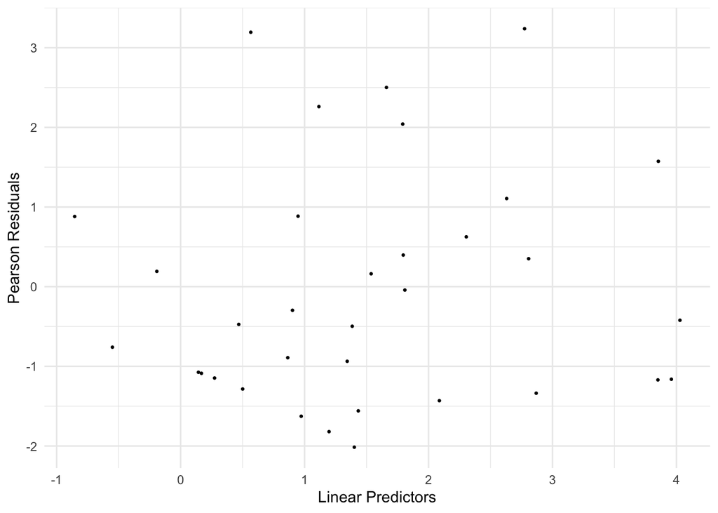

```r
p_resids <- residuals(mod3poisson, type = "pearson")
resid_df <- data.frame(p_resids, linear_pred = mod3poisson$linear.predictors)

ggplot(resid_df, aes(x = linear_pred, y = p_resids)) +
  geom_point(size = 0.5) +
  labs(x = "Linear Predictors", y = "Pearson Residuals") +
  theme_minimal()
```

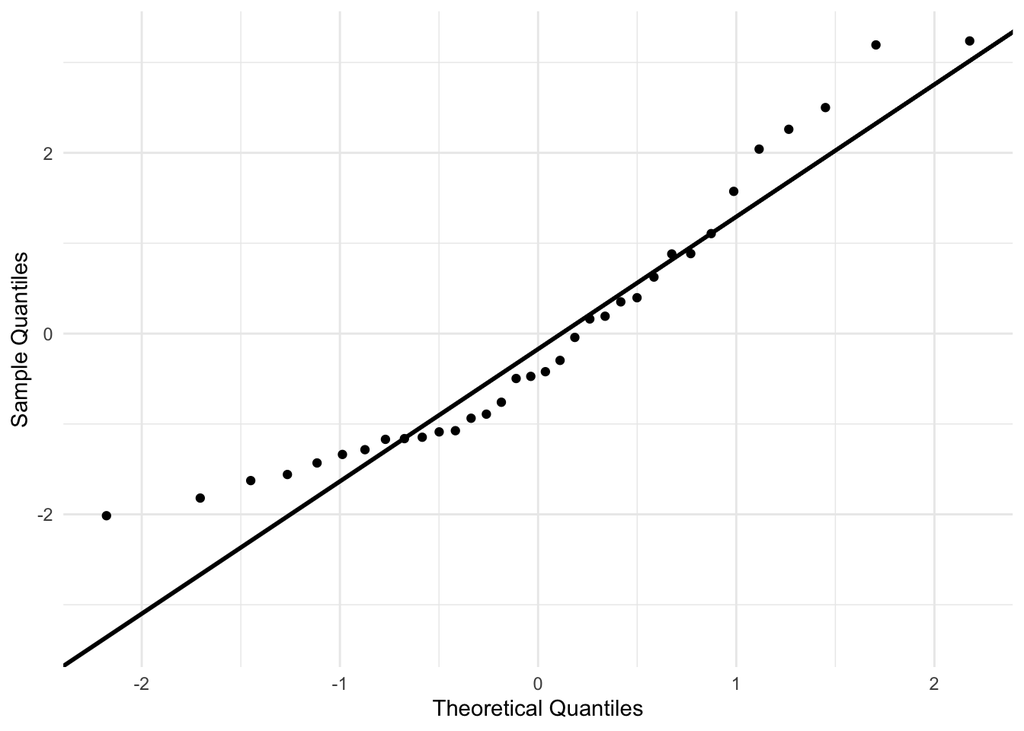

```r
ggplot(resid_df, aes(sample = p_resids)) +
  geom_qq() +
  geom_qq_line(linewidth = 1) +
  labs(x = "Theoretical Quantiles", y = "Sample Quantiles") +
  theme_minimal()
```

Answer: We can see in the residual plot that the assumption random spread is met, as there does not appear to be any significant patterns occuring in the data. However, we see in the QQ Plot that the distribution of pearson redisuals is skewed to the right, which violates the assumption that the residuals are approximately normal.

### Part d (5 points)

Conduct a deviance goodness-of-fit (GOF) test for a lack of fit here. Type out the null and alternative hypotheses, report the test statistic, give the p-value, and provide an interpretation.

```r
print(mod3poisson$deviance)
```

```
[1] 77.44977
```

```r
print(mod3poisson$df.residual)
```

```
[1] 24
```

```r
1 - pchisq(mod3poisson$deviance, df = mod3poisson$df.residual)
```

```
[1] 1.542447e-07
```

```r
mod3poisson$deviance/mod3poisson$df.residual
```

```
[1] 3.227074
```

The GOF test statistic is approximately $3$ times the size of the degrees of freedom, which indicates that there is more variation in the number of ship incidents than the poisson model can account for. This is backed up by the p-value, which is signifiantly smaller than 0.05 (reject the null hypothesis) indicating that there is overwhelming evidence that this poisson model is a poor fit for this data.

### Part e (4 points)

Is there evidence that this model has overdispersion? Explain.

```r
phi <- sum(residuals(mod3poisson, type = "pearson")^2)/mod3poisson$df.residual
phi
```

```
[1] 2.896271
```

Answer: Overdispersion is when the variance of a model is greater than its mean, which in this case violates the fundamental property of the poisson distribution which assumes that the variance is equal to the mean. Because the sum of squared pearson residuals divided by the degrees of freedom (the dispersion) is greater than 1.25, there is evidence of that this model has overdispersion and correction for this is warranted.

### Part f (6 points)

Fit a “quasipoisson” model to these data. Using this model, obtain an approximate 95% confidence interval for the mean response for a ship of type “B” with construction between 1965 and 1969, with operation between 1960 and 1974, and with 2000 aggregate months of service. You can construct this interval using a t critical value with 24 degrees of freedom since the quasipoisson family more closely follows a t distribution than a normal one. Interpret the interval.

```r
mod3quasipoisson <- glm(incidents ~ ., data = ship_accidents, family = "quasipoisson")
summary(mod3quasipoisson)
```

```
Call:
glm(formula = incidents ~ ., family = "quasipoisson", data = ship_accidents)

Coefficients:
                      Estimate Std. Error t value Pr(>|t|)
(Intercept)          2.657e-01  4.724e-01   0.562 0.579020
typeB                7.030e-01  3.722e-01   1.889 0.071078 .
typeC               -1.196e+00  5.574e-01  -2.146 0.042167 *
typeD               -8.320e-01  4.896e-01  -1.699 0.102218
typeE               -2.492e-01  4.017e-01  -0.620 0.540827
construction1965-69  1.048e+00  3.059e-01   3.427 0.002206 **
construction1970-74  1.446e+00  3.854e-01   3.753 0.000982 ***
construction1975-79  6.788e-01  4.721e-01   1.438 0.163364
operation1975-79     7.031e-01  2.311e-01   3.043 0.005604 **
service              6.421e-05  1.462e-05   4.391 0.000196 ***
---
Signif. codes:  0 '***' 0.001 '**' 0.01 '*' 0.05 '.' 0.1 ' ' 1

(Dispersion parameter for quasipoisson family taken to be 2.896314)

    Null deviance: 614.54  on 33  degrees of freedom
Residual deviance:  77.45  on 24  degrees of freedom
AIC: NA

Number of Fisher Scoring iterations: 5
```

```r
incident_pred_quasi <- predict(mod3quasipoisson, data.frame(type = "B", construction = "1965-69", operation = "1960-74", service = 2000), se.fit = T)

t_crit = qt(0.975, df = mod3quasipoisson$df.residual)

tibble(
  Lower = exp(incident_pred_quasi$fit - t_crit * incident_pred_quasi$se.fit),
  Upper = exp(incident_pred_quasi$fit + t_crit * incident_pred_quasi$se.fit)
)
```

```
# A tibble: 1 × 2
  Lower Upper
  <dbl> <dbl>
1  3.66  19.9
```

Answer: We are 95% confident that the average number of incidents a ship of type B that was constructed between 1965 and 1969, was in operation between 1960 and 1974 and was in service for 2000 months had is between 3.66 and 19.9 incidents.

### Part g (5 points)

Now construct an approximate 95% prediction interval for the number of incidents for the ship described in part f using the `qpois()` function. Interpret the interval.

```r
predicted_mean_quasi <- exp(incident_pred_quasi$fit)

tibble(
  lower = qpois(0.025, lambda = predicted_mean_quasi),
  upper = qpois(0.975, lambda = predicted_mean_quasi)
)
```

```
# A tibble: 1 × 2
  lower upper
  <dbl> <dbl>
1     3    15
```

Answer: We are 95% confident that the actual number of incidents a ship of type B that was constructed between 1965 and 1969, was in operation between 1960 and 1974 and was in service for 2000 months had is between 3 and 15 incidents.

### Part h (6 points)

Suppose we did not catch the fact that this model is overdispersed. Repeat parts f and g using the model fit with the “poisson” family, not “quasipoisson” and using a z interval for the mean response rather than a t interval. Compare your results to parts f and g and comment on what is different.

```r
incident_pred_poisson <- predict(mod3poisson, data.frame(type = "B", construction = "1965-69", operation = "1960-74", service = 2000), se.fit = T)

z_crit = 1.96

tibble(
  Lower = exp(incident_pred_poisson$fit - z_crit * incident_pred_poisson$se.fit),
  Upper = exp(incident_pred_poisson$fit + z_crit * incident_pred_poisson$se.fit)
)
```

```
# A tibble: 1 × 2
  Lower Upper
  <dbl> <dbl>
1  5.33  13.7
```

```r
predicted_mean_poisson <- exp(incident_pred_poisson$fit)

tibble(
  lower = qpois(0.025, lambda = predicted_mean_poisson),
  upper = qpois(0.975, lambda = predicted_mean_poisson)
)
```

```
# A tibble: 1 × 2
  lower upper
  <dbl> <dbl>
1     3    15
```

Answer: We can see that using the poisson model and a z-distribution creates a much narrower confidence interval compared to what was calculated using the quasi-poisson model and a t-distribution. This makes sense because this interval is for the average incidents within the specific charactoristic, and the quasi-poisson model is accounting for the overdispersion where the regular poisson distribution is not. We can see that the qpois() confidence intervals are resulting in the same confidence interval, regardless on when the poisson or quasi-poisson models are used. This makes sense because this confidence interval is for the actual incidence a specific ship may have, rather than an average across similar ships.